# Exploring and Analysis lesional psoriasis, with RNA-Seq data

Mustafa ABUELQUMSAN

2017-01-19

# Introduction about Lesional Psoriatic

Psoriasis is a chronic inflammatory disease of the skin and joints, we will use the RNA-Seq based analysis of the psoriatic trascriptome to revealed a large number of differentially experssed genes(DEGs) in the lesional skin.we have case-control comparisons in the lesional and normal skin from the same individual this is in the negative control.Moreover, we will study the non-lesional psoriatic vs. normal skin. Here will we RNA-Seq have more accuracy and precision. we will identifies unmapped trascripts and alternative spicing. and markedly increases the dynamic range detected.

where our working with DNA sequencing(RNA-seq), we generate so many data that, without the help of computers, would be incomprehensible to the human. The transcriptome analysis characterize all transcriptional activity (coding and non-coding), focus on a subset of relevant target genes and transcripts, or profile thousands of genes at once to create a global picture of cell funtion. Li and coworkers [-@Li:2014dp] used RNA-seq to characterize the transcriptome of 92 skin samples of people suffering from psoriasis, and 82 control sample.

# The Goal from this report

1. **Detection and interpretation of differentially expressed genes:** run a statistical analysis of the read counts, in order to detect differentially expressed genes (**DEG**) between psoriasis and control samples [@Li:2014dp], and to study the functional associations of these genes, and provide a biological interpretation of these results.
2. **Methodological evaluation:**
   1. **Robusntess analysis:** analyse the impact of individual particularities of the patients/controls, and measure the impact of the sample size by applying a sub-sampling approach.
   2. **Negative control:** check the reliability of the DEG detection method (DESeq2) by running the same analysis with two subset of samples belonging to the same group.

# 1. Loading the dataset psoriasis:

First, we have to load the psoriasis dataset and check the contents.

**Table: Contents of Psoriasis table** We only display a random selection of 2 samples and 6 rows.

|  | GSM1315790_M9132_Psoriasis_skin_SRX451477 | GSM1315789_M9081_Psoriasis_skin_SRX451476 |
| --- | --- | --- |
| SSX5 | 11 | 44 |
| LRRC46 | 2 | 12 |
| EHF | 17854 | 13099 |
| PPY2 | 0 | 0 |
| EVPL | 7380 | 10612 |
| JRKL | 213 | 96 |

The count table contains 23368 rows and 174 columns.

# 2. Loading the phenotypic data:

| X1 | X2 | X3 | X4 | X5 |
| --- | --- | --- | --- | --- |
| GSM1315790 | M9132 | Psoriasis | skin | SRX451477 |
| GSM1315789 | M9081 | Psoriasis | skin | SRX451476 |
| GSM1315788 | M9049 | Psoriasis | skin | SRX451475 |
| GSM1315787 | M9027 | normal | skin | SRX451474 |
| GSM1315786 | M9004 | normal | skin | SRX451473 |
| GSM1315785 | M9000 | normal | skin | SRX451472 |

The pheno table contains 174 rows (one per sample) and 5 columns (one per sample attribute).

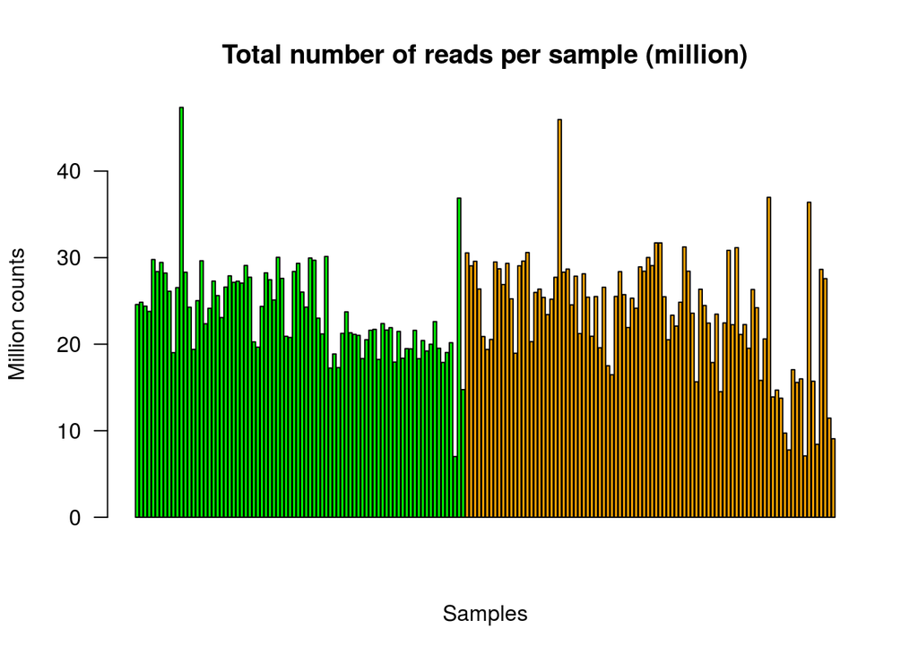

# Descriptive statistics

## Basic statistics

we can show here from the Basic statistics per sample, since these statistics per gene are meaningful only after library-wise normalization of the counts. we have number of sample is 174 and number of Genes is 23368 beside that we noticed all the samples have many from the zero reads, where the percente of zero reads for each Genes in count table is very high. you can notice all these informative information from brif random summary from the milestone values (Mean, median, quartiles)

**Table: statistics per sample.** We only display a random selection of 10 samples.

|  | Min. | X1st.Qu. | Median | Mean | X3rd.Qu. | Max. | perc05 | perc10 | perc90 | perc95 | zeros | percent.zeros |
| --- | --- | --- | --- | --- | --- | --- | --- | --- | --- | --- | --- | --- |
| GSM1315612 Psoriasis | 0 | 4 | 155 | 1180.0 | 842.0 | 994700 | 0 | 0 | 2181.3 | 3636.65 | 4041 | 17.29288 |
| GSM1315694 Psoriasis | 0 | 3 | 128 | 1357.0 | 829.0 | 1946000 | 0 | 0 | 2312.3 | 4030.00 | 4281 | 18.31992 |
| GSM1315742 Psoriasis | 0 | 2 | 87 | 838.4 | 561.0 | 878700 | 0 | 0 | 1539.0 | 2610.95 | 4616 | 19.75351 |
| GSM1315763 Psoriasis | 0 | 4 | 147 | 1267.0 | 914.0 | 806300 | 0 | 0 | 2369.6 | 4085.55 | 4128 | 17.66518 |
| GSM1315633 Psoriasis | 0 | 2 | 71 | 589.0 | 379.0 | 338500 | 0 | 0 | 985.3 | 1738.30 | 4579 | 19.59517 |
| GSM1315741 Psoriasis | 0 | 2 | 105 | 1137.0 | 711.0 | 665000 | 0 | 0 | 1982.0 | 3548.55 | 4587 | 19.62941 |
| GSM1315775 Psoriasis | 0 | 2 | 97 | 879.3 | 629.0 | 552300 | 0 | 0 | 1679.0 | 2907.00 | 4768 | 20.40397 |
| GSM1315789 Psoriasis | 0 | 2 | 101 | 1243.0 | 763.2 | 1006000 | 0 | 0 | 2186.3 | 3938.65 | 4797 | 20.52807 |
| GSM1315754 Psoriasis | 0 | 8 | 265 | 1966.0 | 1415.0 | 2174000 | 0 | 0 | 3655.0 | 6138.95 | 3621 | 15.49555 |
| GSM1315641 Psoriasis | 0 | 3 | 125 | 1036.0 | 760.2 | 514700 | 0 | 0 | 1996.0 | 3417.25 | 4272 | 18.28141 |

**Number of samples per group.**

| Group | Number of samples |
| --- | --- |
| normal | 82 |
| Psoriasis | 92 |

## Distributions

we impose a very large scale on the X axis.so so that We will use a logarithmic transformation to improve the readability. beside that we will add pseudo count to avoid problems with “zero” counts observed for some genes in some samples.

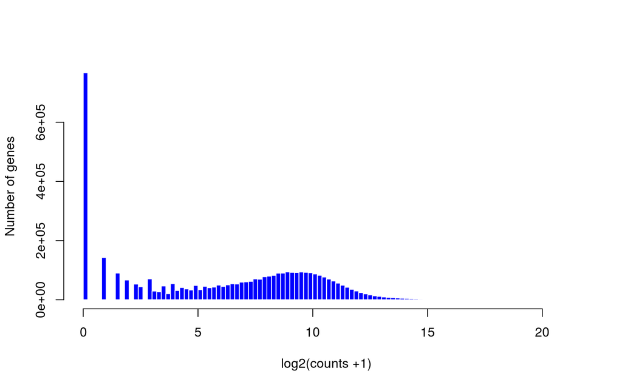

**Histrogram of count table per Gene**

apparently from this Histogram the data are sime discreate data, where we can’t say it is follow the normal distribution.

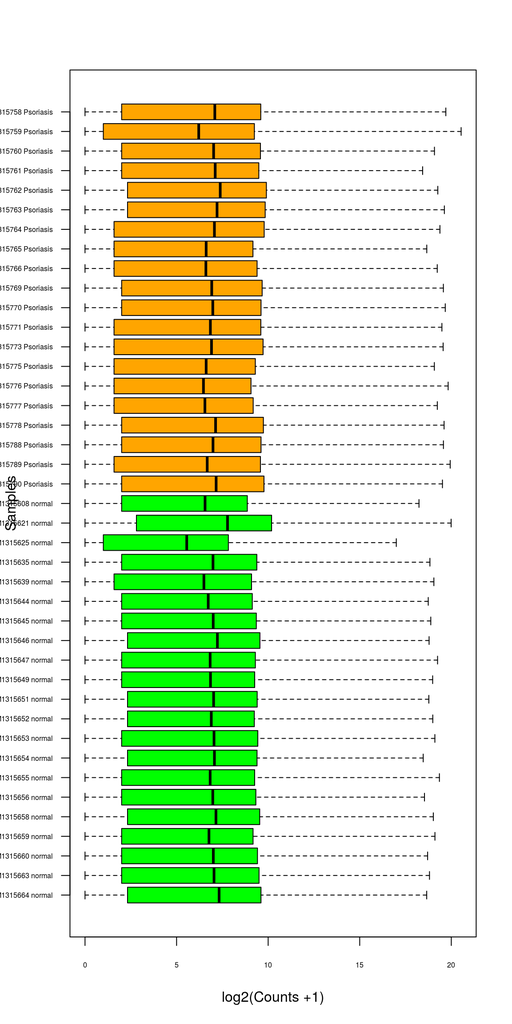

**Box plot of the log2-transofrmed counts, before normalisation**. Each boxplot corresponds to one sample. Colors: orange=prosiasis, green=control.

from that boxplot,it is the time to we can identifiy the outliers and comparing the distributions for each sample in the count table. where in each sample there are many outliers and it is absolutaly the distribution for these samples aren’t follow the Normal distribution where it shortest to discreat distribution. The scatter plot shows if we can have a good reproductibility between the samples of psoriasis and normal skin disease.

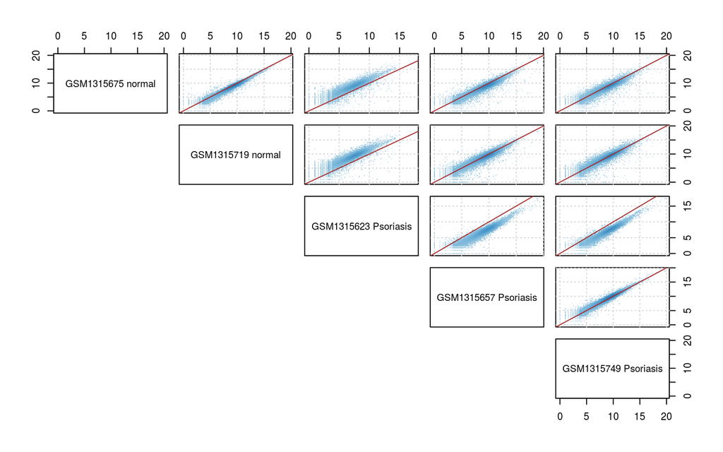

** scatter plot for a pair of variables (samples) with density colors **

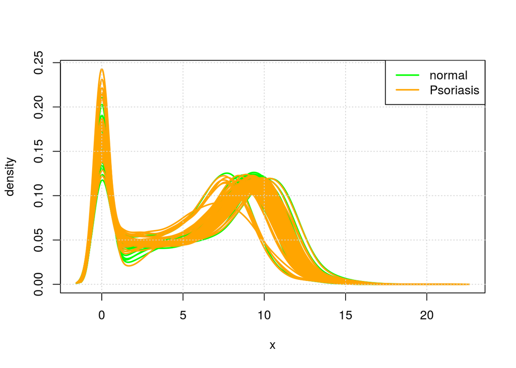

where from the density curve for each sample we can confirm our conclusion about normality of our data.

# Eliminating undetected genes

as from we notecied from our discrptive analysis about our data we seen many zero (null) reads for many genes in Psoriasis genome. as exemplified by from the following barplot we have some genes undetected in any of sample, so that we must to delete them from count Table.

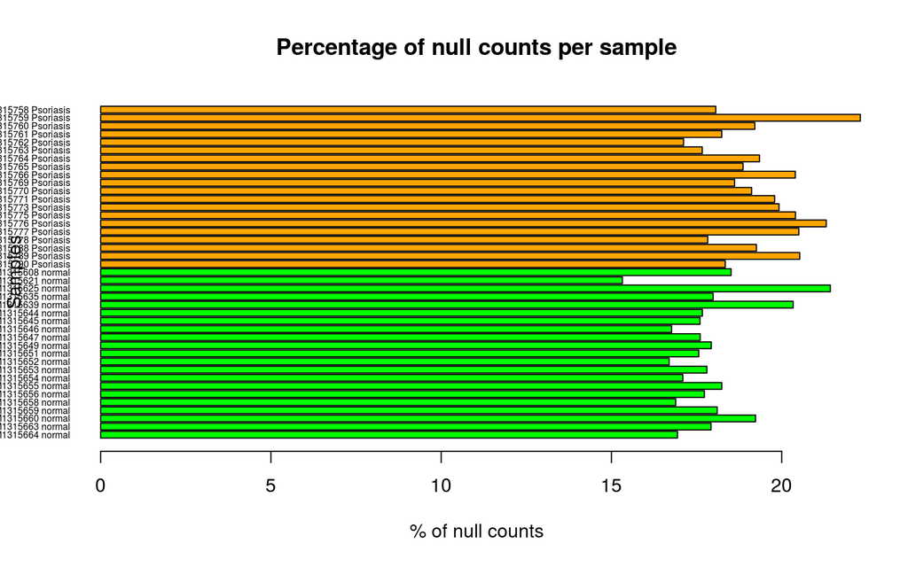

** Undetected genes **

# Selecting randomly samples

The most important question that will drive the analysis will be to define the impact of the number of sample on the analysis. so that, here we used a high number of replicates (**25 replicates**) for the analysis.

```
We would be used DESeq owing to minimizing false positives is more important and DESeq absolutely exceeds the other tools.
```

# Detect differentially expressed genes

## Creating a DESeqDataSet dataset

```
class: DESeqDataSet
dim: 22061 50
metadata(1): version
assays(1): counts
rownames(22061): 1/2-SBSRNA4 A1BG ... ZZZ3 tAKR
rowData names(0):
colnames(50): GSM1315635 normal GSM1315691 normal ... GSM1315617
  Psoriasis GSM1315754 Psoriasis
colData names(6): GSM_ID M_ID ... SRX_ID color
```

## Normalization

We can be used The method estimateSizeFactors() associated with normalization for the “CountDataSet” class. Here’s a short view of the result:

```
GSM1315617 Psoriasis    GSM1315684 normal    GSM1315691 normal
           0.7126532            0.6425611            0.9677304
GSM1315670 Psoriasis    GSM1315635 normal    GSM1315646 normal
           1.2113716            1.0278608            1.2090420
```

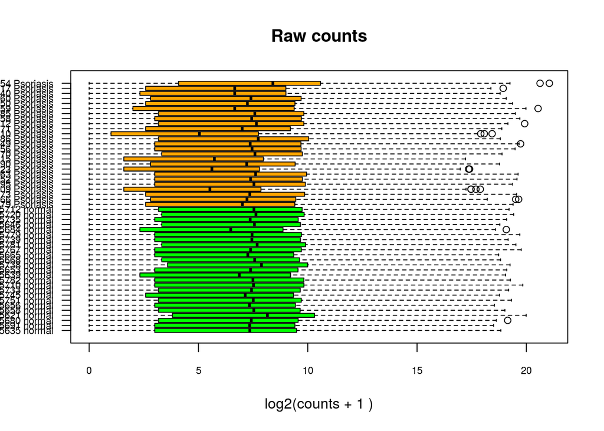

## Count variance is related to mean

Here it is instructive to look at how the variance is related to the mean by computing and displaying them in a plot. let’s to compute some of the statistics:

|  | min | mean | median | max | zeros | percent.zeros | perc10 | perc20 | perc50 | perc90 | perc95 |
| --- | --- | --- | --- | --- | --- | --- | --- | --- | --- | --- | --- |
| GSM1315690 Psoriasis | 0 | 975.9560 | 154.3168 | 470947.6 | 3108 | 14.08821 | 0 | 2.099549 | 154.3168 | 1759.422 | 3085.287 |
| GSM1315763 Psoriasis | 0 | 983.8265 | 142.9663 | 591181.7 | 2821 | 12.78727 | 0 | 2.199481 | 142.9663 | 1823.370 | 3107.867 |
| GSM1315759 Psoriasis | 0 | 1345.8210 | 112.6133 | 1712881.6 | 3906 | 17.70545 | 0 | 1.126133 | 112.6133 | 2147.536 | 3866.016 |
| GSM1315691 normal | 0 | 883.8444 | 166.3687 | 383466.3 | 2832 | 12.83713 | 0 | 3.100037 | 166.3687 | 1687.454 | 2824.134 |
| GSM1315615 Psoriasis | 0 | 1081.8558 | 147.1997 | 431668.7 | 3961 | 17.95476 | 0 | 2.830763 | 147.1997 | 1834.334 | 3232.731 |
| GSM1315617 Psoriasis | 0 | 1000.0497 | 140.3207 | 706229.9 | 3650 | 16.54503 | 0 | 2.806414 | 140.3207 | 1937.829 | 3307.359 |
| GSM1315735 normal | 0 | 1020.8291 | 152.9722 | 523831.0 | 3020 | 13.68932 | 0 | 2.798272 | 152.9722 | 1791.827 | 3056.646 |
| GSM1315712 normal | 0 | 971.7148 | 152.4312 | 499222.9 | 2738 | 12.41104 | 0 | 2.471858 | 152.4312 | 1746.779 | 2948.102 |
| GSM1315782 normal | 0 | 1033.9028 | 143.8586 | 507242.0 | 2958 | 13.40828 | 0 | 2.411037 | 143.8586 | 1889.449 | 3272.581 |
| GSM1315739 normal | 0 | 989.5371 | 150.8977 | 512697.2 | 2920 | 13.23603 | 0 | 2.616723 | 150.8977 | 1794.200 | 3066.799 |

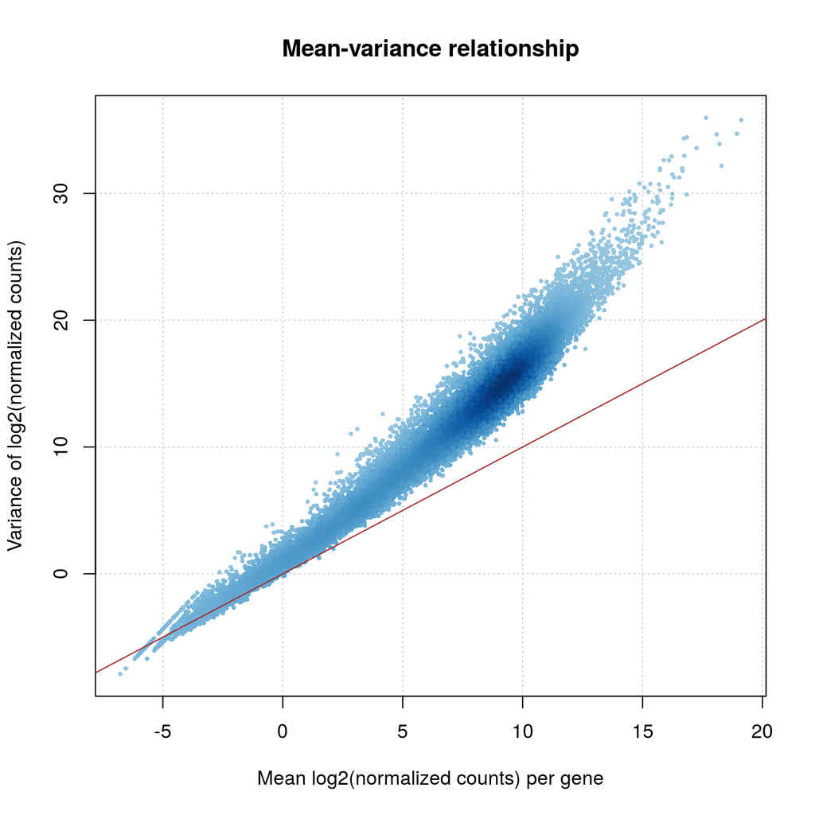

**Figure: variance/mean plot.** The brown line highlights $x=y$, which corresponds to the expected relationship between mean and variance for a Poisson distribution.

## Modelling read counts through a negative binomial

*from this Figure* we seen the brown line highlights
$$x=Y$$
which shown the expected relationship between mean and variance for a poisson distribution.

## Using mean and dispersion

we would using second way to parametrizing the distribution by using mean value $m$ and the dispersion parameter r. we thus can compute the variance of distribution

## Modelling read counts through a negative binomial Distribution.

we use the DESeq to perform differntial expression by assuming for each gene the read counts are generated by a negative Bionomial distribution, the essential problem here will be to estimate, for each gene, the two parameters of the negative bionomial distribution: mean and dispersion. - The mean will be estimated from the observed normalized counts in both conditions. - the procedures will be to compute a gene-wise dispersion. when the number of available samples is insufficient to obtain a reliable estimator of the variance for each gene, DESeq will apply *a shrinkage Strategy* which assumes that counts produced by genes with similar expression level(counts) have the similar variance.

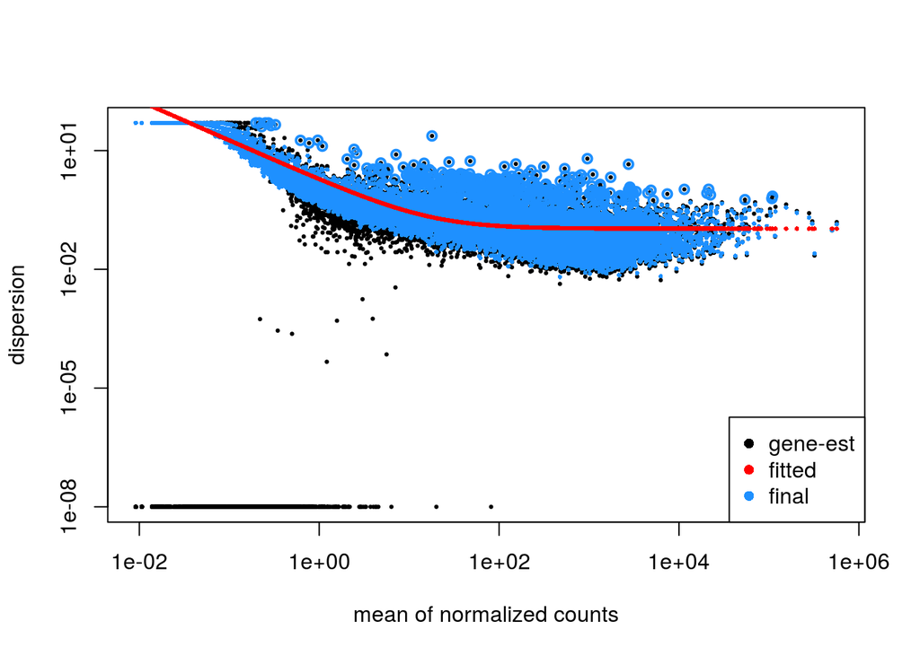

## Performing differential expression call

Now that a negative binomial model has been fitted for each gene, the nbinomWaldTest can be used to test for differential expression. The output is a data.frame which contains nominal p-values, as well as FDR values (correction for multiple tests computed with the Benjamini-Hochberg procedure).

```
log2 fold change (MAP): Group Psoriasis vs normal
Wald test p-value: Group Psoriasis vs normal
DataFrame with 6 rows and 6 columns
               baseMean log2FoldChange      lfcSE        stat       pvalue
              <numeric>      <numeric>  <numeric>   <numeric>    <numeric>
1/2-SBSRNA4   10.704801    -0.19193524 0.18799369 -1.02096637 3.072704e-01
A1BG          35.541777     0.01772027 0.20718888  0.08552712 9.318423e-01
A1BG-AS1       8.183624     0.10276625 0.21042161  0.48838260 6.252789e-01
A1CF           1.625805     0.14138721 0.39465293  0.35825708 7.201509e-01
A2LD1         90.604783     0.10463601 0.06987256  1.49752640 1.342563e-01
A2M         9100.263709    -0.62845666 0.10549932 -5.95697339 2.569521e-09
                    padj
               <numeric>
1/2-SBSRNA4 3.919486e-01
A1BG        9.498530e-01
A1BG-AS1    7.010223e-01
A1CF        7.815971e-01
A2LD1       1.934226e-01
A2M         1.450993e-08
```

Then we can order the table by the p-value to show the most significant entries.

```
log2 fold change (MAP): Group Psoriasis vs normal
Wald test p-value: Group Psoriasis vs normal
DataFrame with 6 rows and 6 columns
         baseMean log2FoldChange     lfcSE      stat        pvalue
        <numeric>      <numeric> <numeric> <numeric>     <numeric>
PI3     30099.965       9.152324 0.2645698  34.59323 3.194312e-262
AKR1B10  1644.498       6.000883 0.1749614  34.29832 8.313059e-258
SPRR2A  25771.496       7.137757 0.2170567  32.88430 3.685651e-237
S100A8  70217.243       7.760198 0.2556857  30.35053 2.472037e-202
DEFB4A   4878.735      11.087226 0.3847169  28.81918 1.233565e-182
S100A7A 20468.920       9.512065 0.3420942  27.80540 3.732198e-170
                 padj
            <numeric>
PI3     6.371055e-258
AKR1B10 8.290198e-254
SPRR2A  2.450343e-233
S100A8  1.232620e-198
DEFB4A  4.920691e-179
S100A7A 1.240645e-166
```

## Histogram plot

Let’s have a notice a histogram of these data.

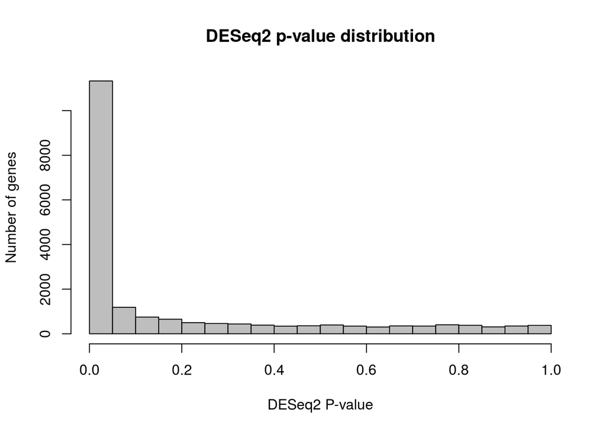

We can deduce that many of these genes have a low p-value.

## Volcano plot

The volcano gives us an idea about the fold changes of the genes and the most significant ones. The farther, the more is differentially expressed.

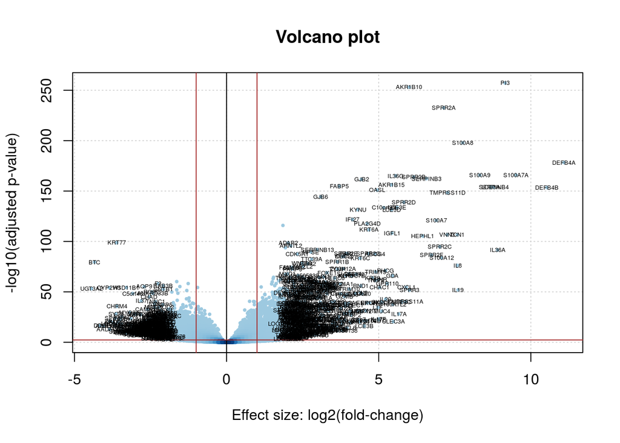

The threshold for the adjused value is **0.005**.